# Red Wine Quality Exploration by Shaden Alsubayhin

# Introduction

This project will apply exploratory data analysis techniques using R to data set that contains 1,599 red wines with 12 variables on the chemical properties of the wine.

# Summary of the Data Set

```
## [1] 1599   13
```

```
## 'data.frame':    1599 obs. of  13 variables:
##  $ X                   : int  1 2 3 4 5 6 7 8 9 10 ...
##  $ fixed.acidity       : num  7.4 7.8 7.8 11.2 7.4 7.4 7.9 7.3 7.8 7.5 ...
##  $ volatile.acidity    : num  0.7 0.88 0.76 0.28 0.7 0.66 0.6 0.65 0.58 0.5 ...
##  $ citric.acid         : num  0 0 0.04 0.56 0 0 0.06 0 0.02 0.36 ...
##  $ residual.sugar      : num  1.9 2.6 2.3 1.9 1.9 1.8 1.6 1.2 2 6.1 ...
##  $ chlorides           : num  0.076 0.098 0.092 0.075 0.076 0.075 0.069 0.065 0.073 0.071 ...
##  $ free.sulfur.dioxide : num  11 25 15 17 11 13 15 15 9 17 ...
##  $ total.sulfur.dioxide: num  34 67 54 60 34 40 59 21 18 102 ...
##  $ density             : num  0.998 0.997 0.997 0.998 0.998 ...
##  $ pH                  : num  3.51 3.2 3.26 3.16 3.51 3.51 3.3 3.39 3.36 3.35 ...
##  $ sulphates           : num  0.56 0.68 0.65 0.58 0.56 0.56 0.46 0.47 0.57 0.8 ...
##  $ alcohol             : num  9.4 9.8 9.8 9.8 9.4 9.4 9.4 10 9.5 10.5 ...
##  $ quality             : int  5 5 5 6 5 5 5 7 7 5 ...
```

```
##        X          fixed.acidity   volatile.acidity  citric.acid
##  Min.   :   1.0   Min.   : 4.60   Min.   :0.1200   Min.   :0.000
##  1st Qu.: 400.5   1st Qu.: 7.10   1st Qu.:0.3900   1st Qu.:0.090
##  Median : 800.0   Median : 7.90   Median :0.5200   Median :0.260
##  Mean   : 800.0   Mean   : 8.32   Mean   :0.5278   Mean   :0.271
##  3rd Qu.:1199.5   3rd Qu.: 9.20   3rd Qu.:0.6400   3rd Qu.:0.420
##  Max.   :1599.0   Max.   :15.90   Max.   :1.5800   Max.   :1.000
##  residual.sugar     chlorides       free.sulfur.dioxide
##  Min.   : 0.900   Min.   :0.01200   Min.   : 1.00
##  1st Qu.: 1.900   1st Qu.:0.07000   1st Qu.: 7.00
##  Median : 2.200   Median :0.07900   Median :14.00
##  Mean   : 2.539   Mean   :0.08747   Mean   :15.87
##  3rd Qu.: 2.600   3rd Qu.:0.09000   3rd Qu.:21.00
##  Max.   :15.500   Max.   :0.61100   Max.   :72.00
##  total.sulfur.dioxide    density             pH          sulphates
##  Min.   :  6.00       Min.   :0.9901   Min.   :2.740   Min.   :0.3300
##  1st Qu.: 22.00       1st Qu.:0.9956   1st Qu.:3.210   1st Qu.:0.5500
##  Median : 38.00       Median :0.9968   Median :3.310   Median :0.6200
##  Mean   : 46.47       Mean   :0.9967   Mean   :3.311   Mean   :0.6581
##  3rd Qu.: 62.00       3rd Qu.:0.9978   3rd Qu.:3.400   3rd Qu.:0.7300
##  Max.   :289.00       Max.   :1.0037   Max.   :4.010   Max.   :2.0000
##     alcohol         quality
##  Min.   : 8.40   Min.   :3.000
##  1st Qu.: 9.50   1st Qu.:5.000
##  Median :10.20   Median :6.000
##  Mean   :10.42   Mean   :5.636
##  3rd Qu.:11.10   3rd Qu.:6.000
##  Max.   :14.90   Max.   :8.000
```

Our dataset contains 1599 observations and 13 variables. The structure shows that all the variables are classified as numerical exept the Quality variable is provided as integer and the X variable is like an index.

```
##
##   3   4   5   6   7   8
##  10  53 681 638 199  18
```

Count of wines by ratings. We can clearly see that the highest ratings are 5 then 6.

# Univariate Plots Section

## Quality

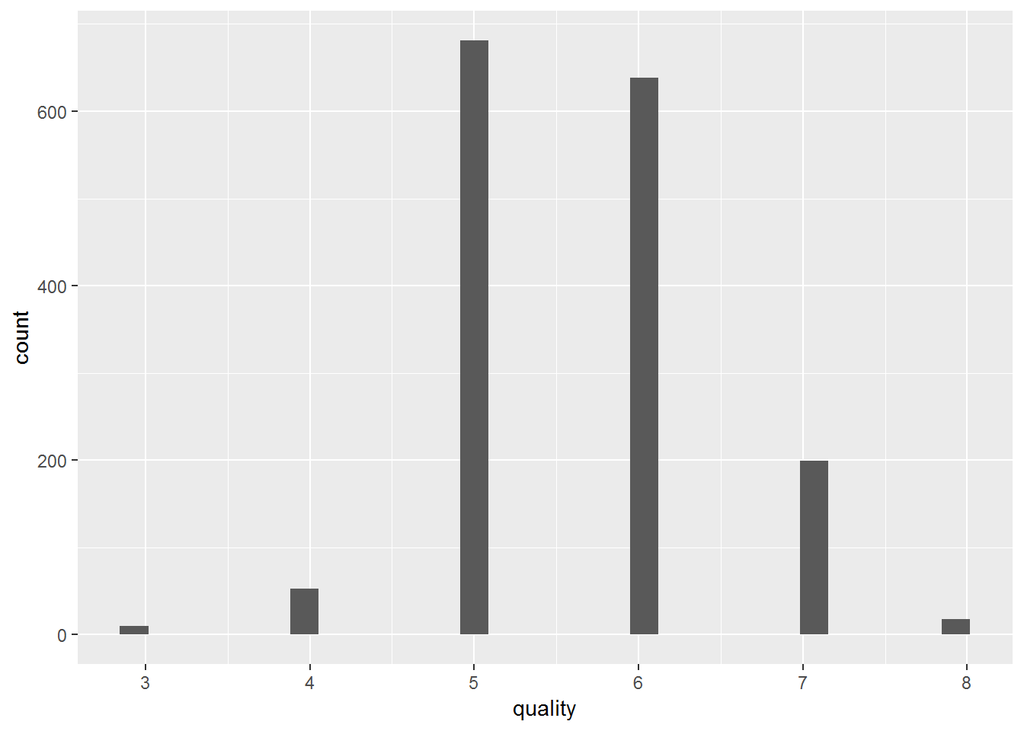

```
##    Min. 1st Qu.  Median    Mean 3rd Qu.    Max.
##   3.000   5.000   6.000   5.636   6.000   8.000
```

As shown in the histogram, the quality ratings range from 3 to 8.

## Fixed Acidity

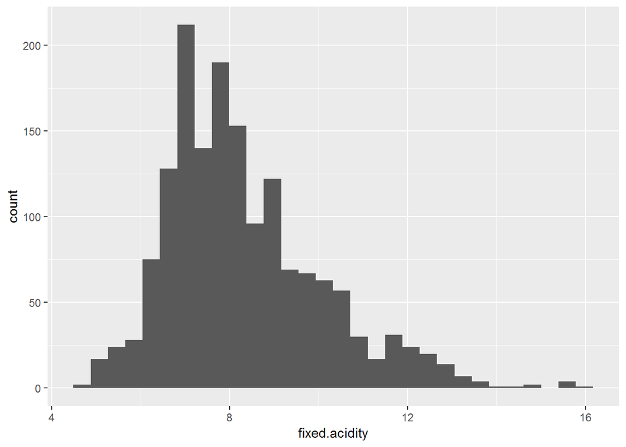

```
##    Min. 1st Qu.  Median    Mean 3rd Qu.    Max.
##    4.60    7.10    7.90    8.32    9.20   15.90
```

The histogram a little right-skewed distributed with some outliers located at right side. The most frequent values are between 7-8.

## Volatile Acidity

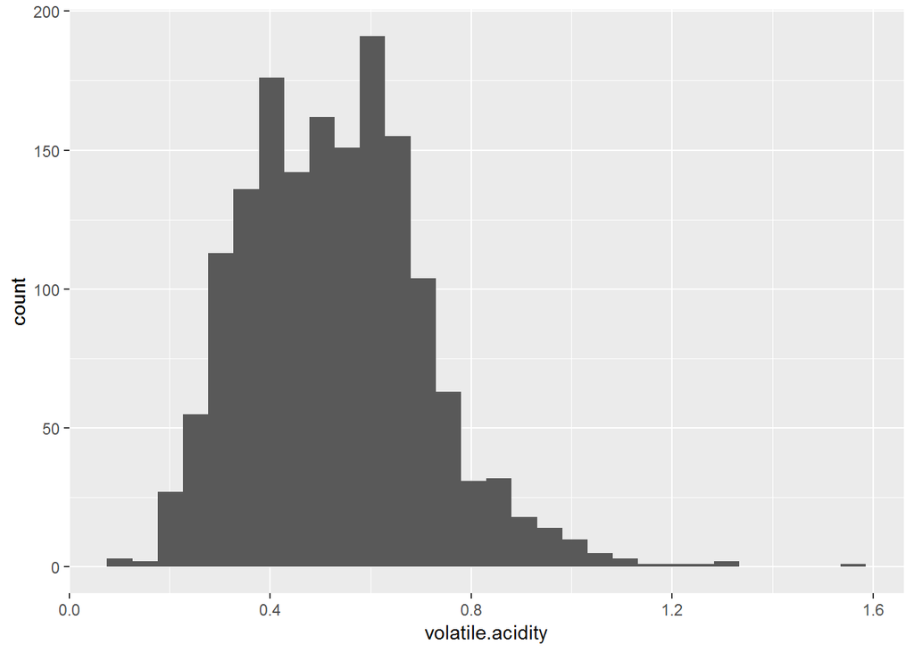

The histogram is right-skewed distributed with some outliers

## Citric Acid

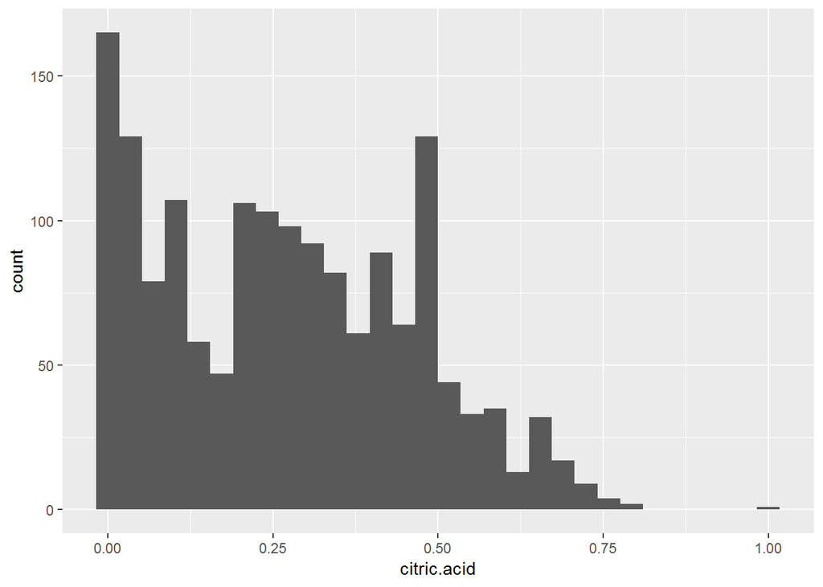

```
##    Min. 1st Qu.  Median    Mean 3rd Qu.    Max.
##   0.000   0.090   0.260   0.271   0.420   1.000
```

The histogram is right-skewed distributed with outliers in the right side , The most frequent value is 0.

## Residual Sugar

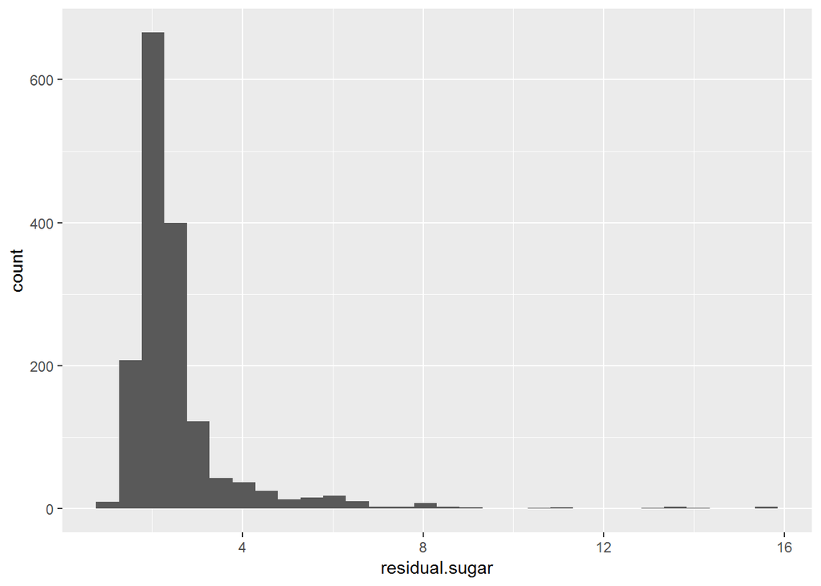

```
##    Min. 1st Qu.  Median    Mean 3rd Qu.    Max.
##   0.900   1.900   2.200   2.539   2.600  15.500
```

This histogram is right-skewed distributed with a lot of outliers with high peak at around 2.

## Chlorides

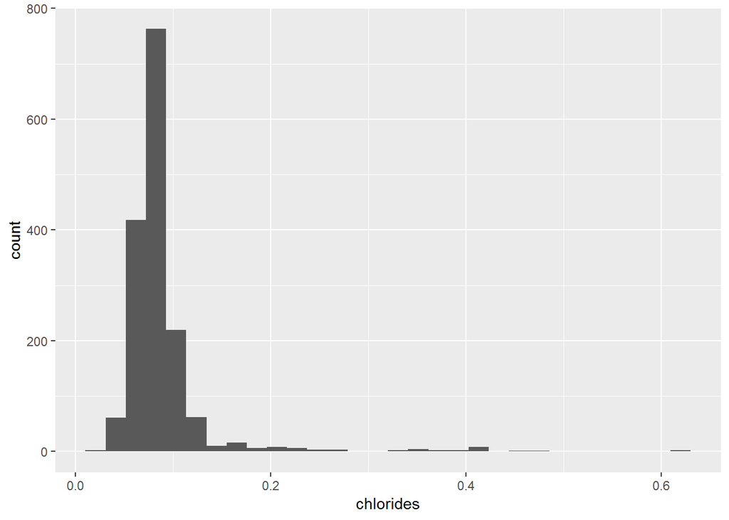

```
##    Min. 1st Qu.  Median    Mean 3rd Qu.    Max.
## 0.01200 0.07000 0.07900 0.08747 0.09000 0.61100
```

This histogram is right skewed with a lot of outliers.

## Density

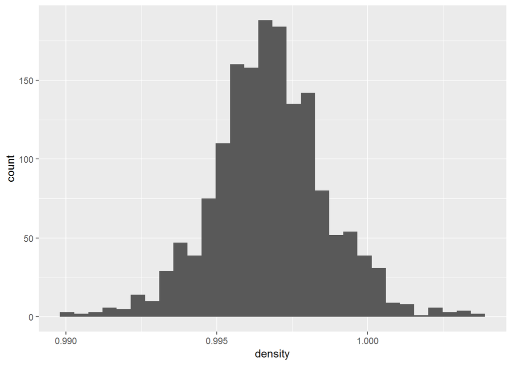

```
##    Min. 1st Qu.  Median    Mean 3rd Qu.    Max.
##  0.9901  0.9956  0.9968  0.9967  0.9978  1.0037
```

This histogram seems normally distributed.

## PH

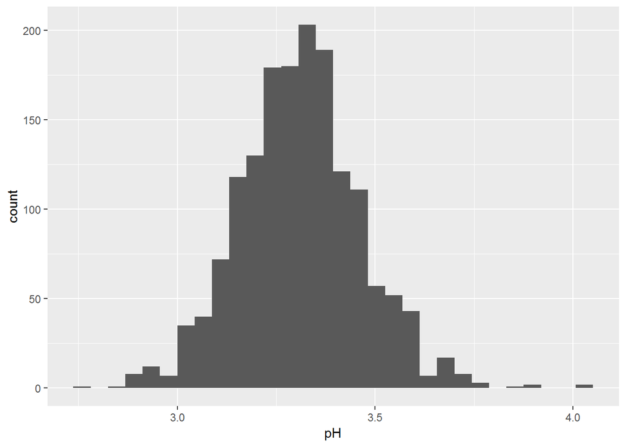

```
##    Min. 1st Qu.  Median    Mean 3rd Qu.    Max.
##   2.740   3.210   3.310   3.311   3.400   4.010
```

The histogram is normally distributed ,The most frequent value is around 3.3 .

## Sulphates

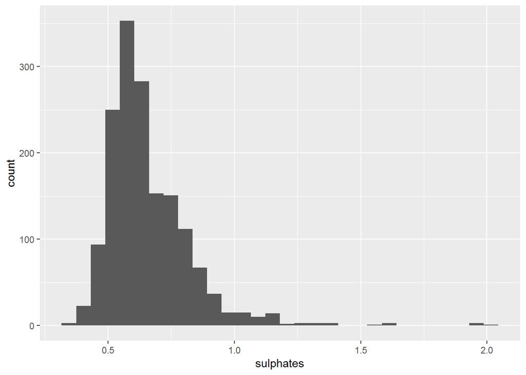

```
##    Min. 1st Qu.  Median    Mean 3rd Qu.    Max.
##  0.3300  0.5500  0.6200  0.6581  0.7300  2.0000
```

The histogram is a little bit right-skewed distributed with some outliers located at right side. The most frequent values are between 0.5-0.7 .

## Alcohol

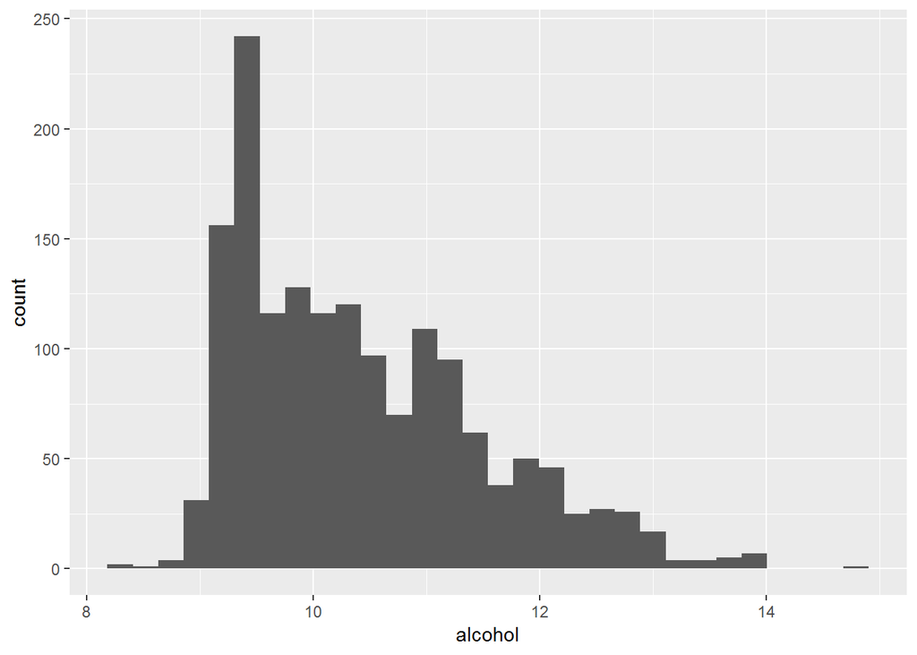

```
##    Min. 1st Qu.  Median    Mean 3rd Qu.    Max.
##    8.40    9.50   10.20   10.42   11.10   14.90
```

The histogram is right-skewed distributed with some outliers on the right side. The most frequent values are around 9.5 .

# Univariate Analysis

### What is the structure of your dataset?

The red wine quality dataset include 1599 observations and 13 variables.11 of them are numeric , 1 variable which is the ‘quality’ is integer and variable X is consider as an index for each observation.

### What is/are the main feature(s) of interest in your dataset?

The main feature of interest is the quality , acohol %, pH, density, citric acid and volatile acidity.

### What other features in the dataset do you think will help support your into your feature(s) of interest?

Volatile acidity, citric acid, and alcohol likely contribute to the quality of a wine. I think volatile acidity (the amount of acetic acid in wine) and alcohol (the percent alcohol content of the wine) probably contribute most to the quality after researching information on wine quality.

### Did you create any new variables from existing variables in the dataset?

No, I didn’t create any new variables.

### Of the features you investigated, were there any unusual distributions? you perform any operations on the data to tidy, adjust, or change the form the data? If so, why did you do this?

Since the data is cleaned and tidy, I didn’t perfomr any cleaning process. I realized most of graphs are right skewed with some outliers.

# Bivariate Plots Section

First lets look at the correlation matrix which will help us to identify the potential related variables.

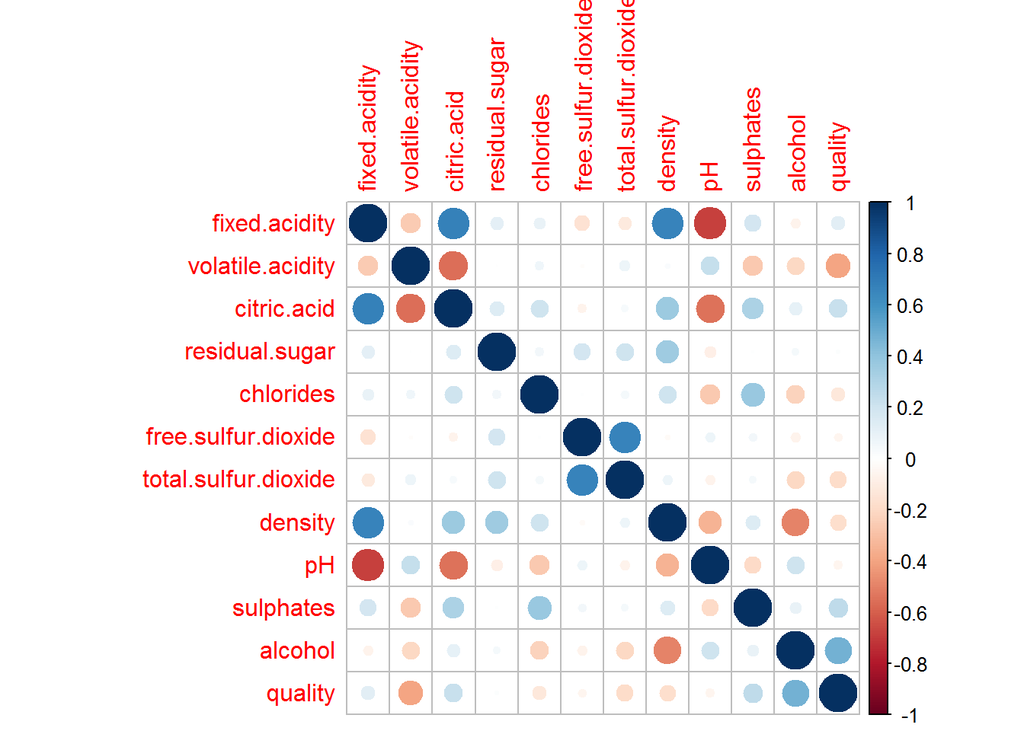

Positive correlations are displayed in blue and negative correlations in red color. Color intensity and the size of the circle are proportional to the correlation coefficients. In the right side of the correlogram, the legend color shows the correlation coefficients and the corresponding colors.

Some potential positively related variable pairs are (citric.acid and fixed.acidity) , (density and residual.sugar) , (density and citric.acid) , (alcohol and quality)

Some potential negatively related variable pairs are (pH and fixed.acidity) , (pH and citric.acid) , (citric.acid and volatile.acidity) , (alcohol and density)

## Citric Acid VS Fixed Acidity

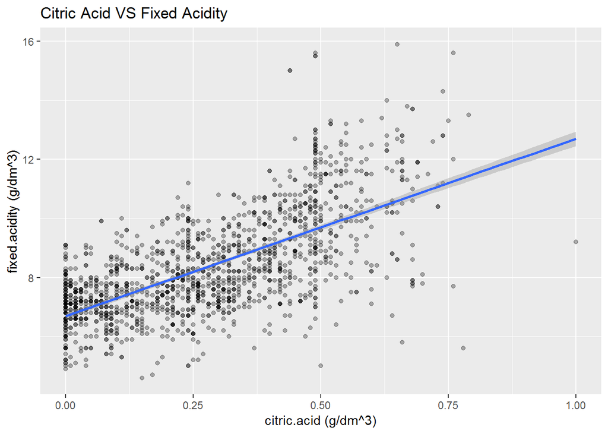

```
##
##  Pearson's product-moment correlation
##
## data:  df$citric.acid and df$fixed.acidity
## t = 36.234, df = 1597, p-value < 2.2e-16
## alternative hypothesis: true correlation is not equal to 0
## 95 percent confidence interval:
##  0.6438839 0.6977493
## sample estimates:
##       cor
## 0.6717034
```

This positive correlation can be due to the fact that citric acid provides solid support to fixed acidity.

## Density vs Residual sugar

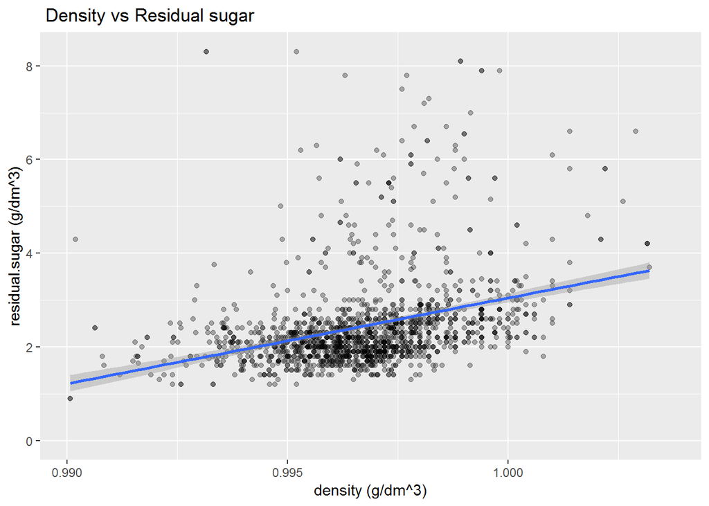

```
##
##  Pearson's product-moment correlation
##
## data:  df$density and df$residual.sugar
## t = 15.189, df = 1597, p-value < 2.2e-16
## alternative hypothesis: true correlation is not equal to 0
## 95 percent confidence interval:
##  0.3116908 0.3973835
## sample estimates:
##       cor
## 0.3552834
```

## Density VS Citric Acid

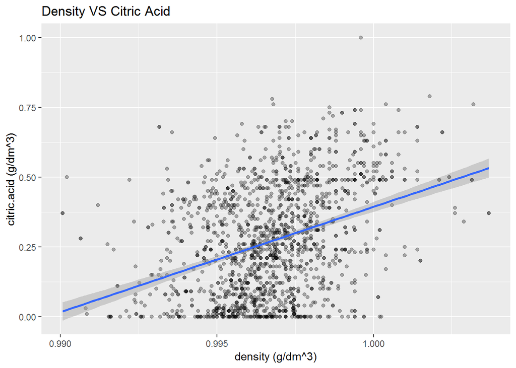

```
##
##  Pearson's product-moment correlation
##
## data:  df$density and df$citric.acid
## t = 15.665, df = 1597, p-value < 2.2e-16
## alternative hypothesis: true correlation is not equal to 0
## 95 percent confidence interval:
##  0.3216809 0.4066925
## sample estimates:
##       cor
## 0.3649472
```

This is a weak slightly positive correlation between density and citric.acid.

## Quality VS Alcohol

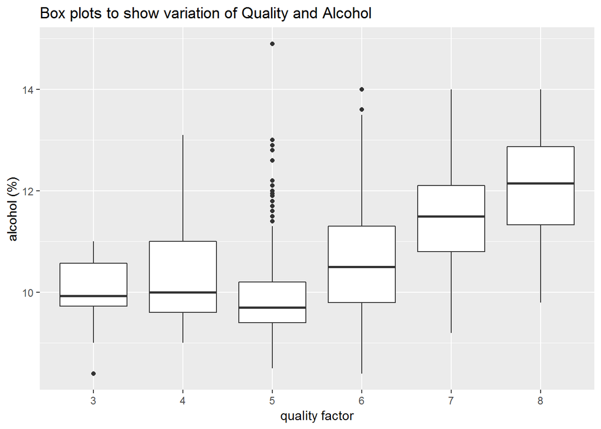

The boxplots shows that wines with quality 6,7, and 8 have higher alcohol percentages.This shows that with high percentage of alcohol, the quality of wine will be better.

## pH VS Fixed Acidity

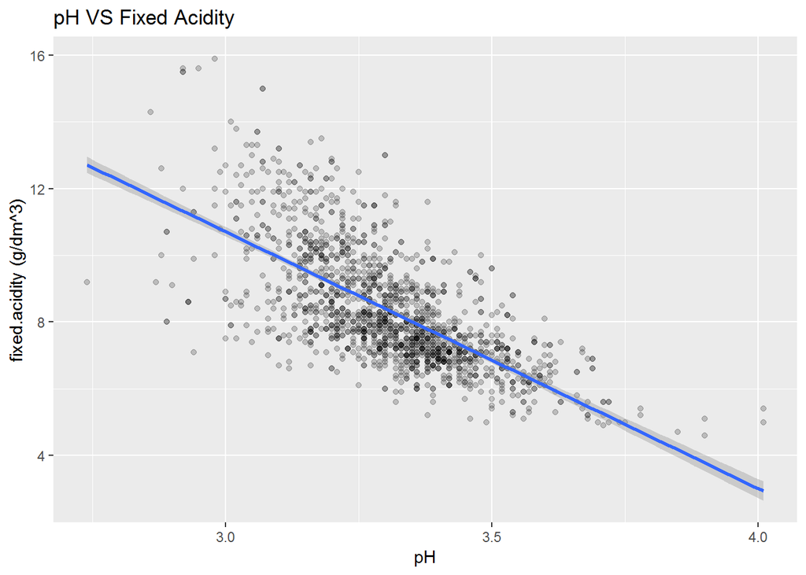

```
##
##  Pearson's product-moment correlation
##
## data:  df$pH and df$fixed.acidity
## t = -37.366, df = 1597, p-value < 2.2e-16
## alternative hypothesis: true correlation is not equal to 0
## 95 percent confidence interval:
##  -0.7082857 -0.6559174
## sample estimates:
##        cor
## -0.6829782
```

There is negative correlation between pH and fixed.acidity , Which means with highest pH we get lowest fixed.acidity value.

## pH VS Citric Acid

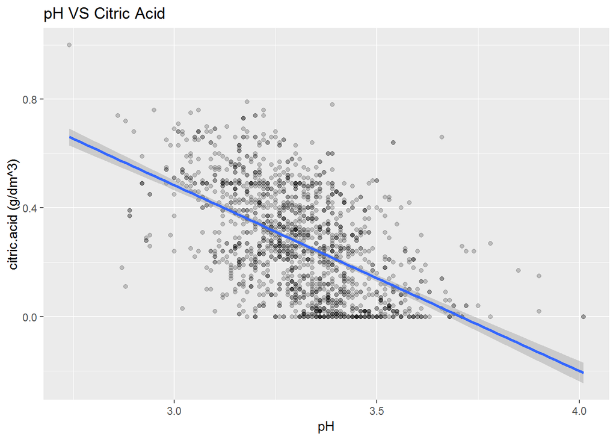

```
##
##  Pearson's product-moment correlation
##
## data:  df$pH and df$citric.acid
## t = -25.767, df = 1597, p-value < 2.2e-16
## alternative hypothesis: true correlation is not equal to 0
## 95 percent confidence interval:
##  -0.5756337 -0.5063336
## sample estimates:
##        cor
## -0.5419041
```

There is negative correlation between pH and citric.acid , Which means with highest pH we get lowest citric.acid value.

## Citric Acid VS Volatile Acidity

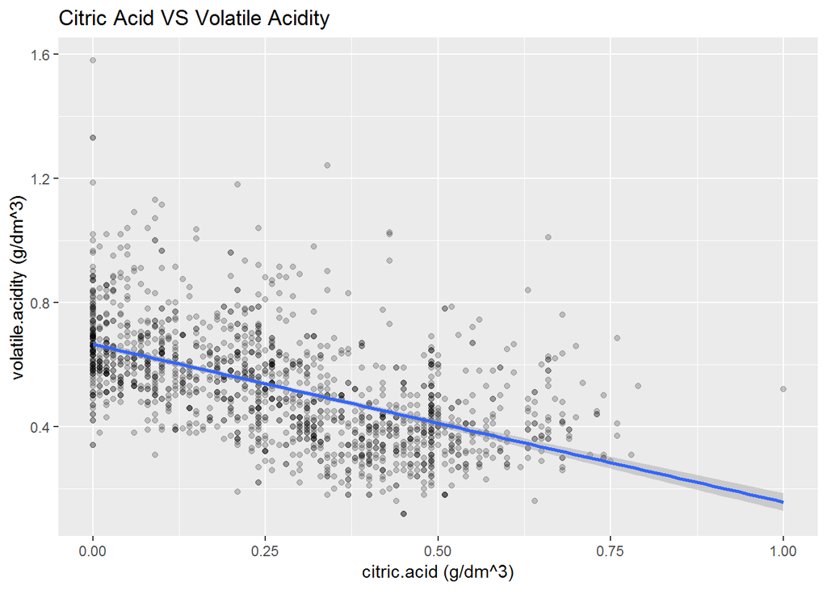

```
##
##  Pearson's product-moment correlation
##
## data:  df$citric.acid and df$volatile.acidity
## t = -26.489, df = 1597, p-value < 2.2e-16
## alternative hypothesis: true correlation is not equal to 0
## 95 percent confidence interval:
##  -0.5856550 -0.5174902
## sample estimates:
##        cor
## -0.5524957
```

There is a negative correlation between citric acid and volatile acidity.

## Alcohol VS Density

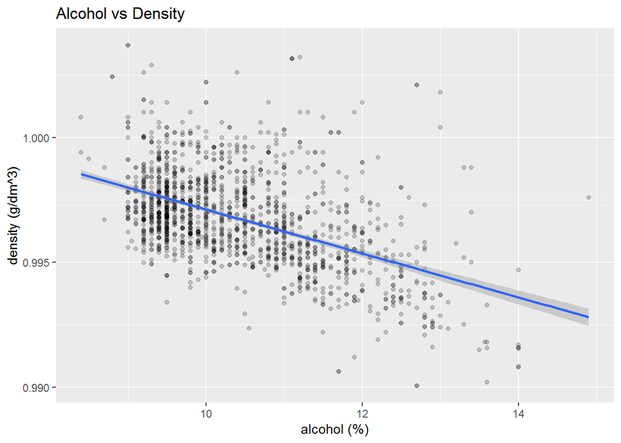

```
##
##  Pearson's product-moment correlation
##
## data:  df$alcohol and df$density
## t = -22.838, df = 1597, p-value < 2.2e-16
## alternative hypothesis: true correlation is not equal to 0
## 95 percent confidence interval:
##  -0.5322547 -0.4583061
## sample estimates:
##        cor
## -0.4961798
```

There is negative correlation between density and alcohol. Which means the percent of alcohol increases and the density decreases.

# Bivariate Analysis

### Talk about some of the relationships you observed in this part of the investigation. How did the feature(s) of interest vary with other features in the dataset?

I found that greater percentage of alcohol results in good quality of wine, Also density and citric.acid / residual sugar shows a positive trend which is really as it should be as these chemicals adds in to the density.

# Multivariate Plots Section

## Alcohol vs Volatile acidity by Quality

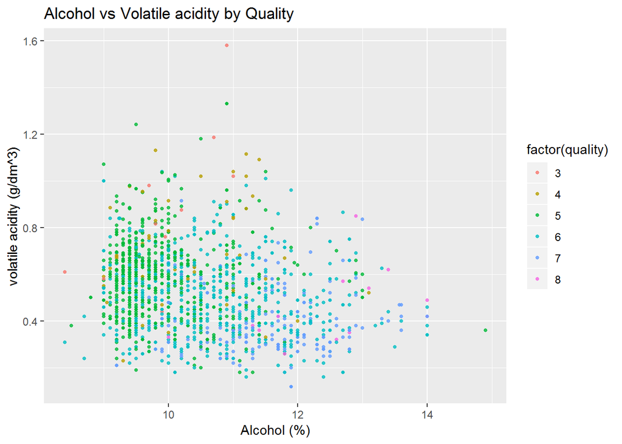

We can see the low quality wines at low alcohol and high volatile acidity.The High quality wines at High alcohol and low volatile acidity.

## Alcohol vs Density by Quality

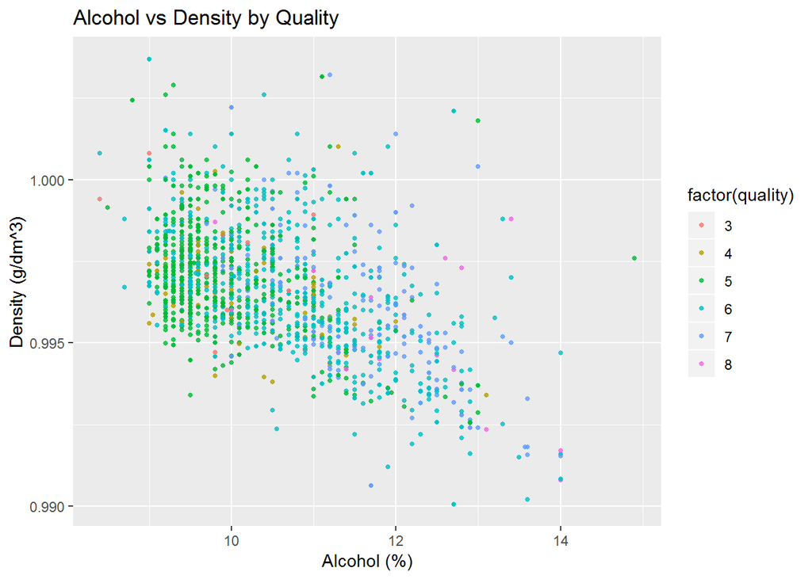

There is a strong negative relationship between alcohol and density,the wine quality increase as the density decrease and alcohol increase.

## Alcohol vs Citric acid by Quality

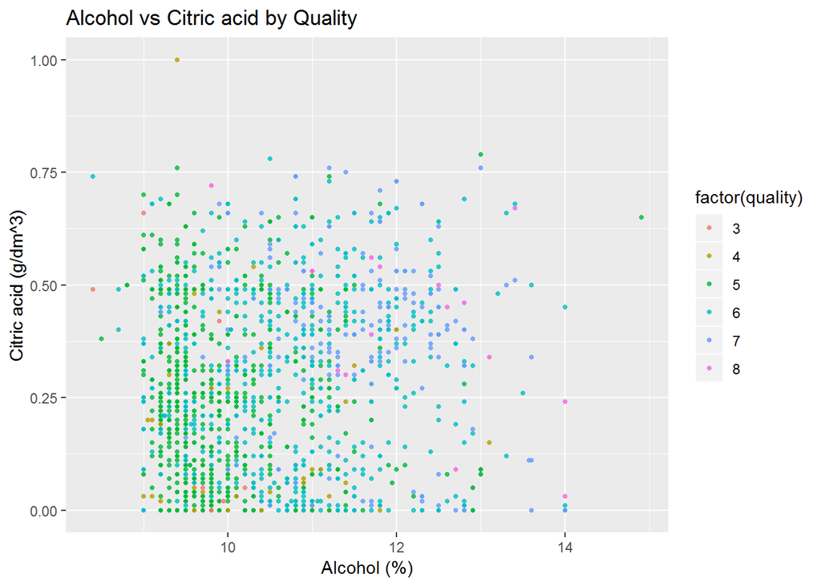

The increase of both alcohol and citric acid tends to give higher quality wines. We also see wines with quality 5 on a wide range of citric acid levels at low alcohol and we see also high quality wines with low citric acid.

# Multivariate Analysis

### Talk about some of the relationships you observed in this part of the . Were there features that strengthened each other in terms of at your feature(s) of interest?

We have seen how alcohol and volatile acidity relate with quality. Higher alcohol and lower acidity give in general better quality wines. And we see that low density and high alcohol tend to give a higher quality wines. We also see that higher amounts of citric acid with higher alcohol gives the best wines.

### Were there any interesting or surprising interactions between features?

An interesting thing to me is the realtion between alcohol and quality , the more alcohol the wines contain the higher quality they have.

# Final Plots and Summary

### Plot One

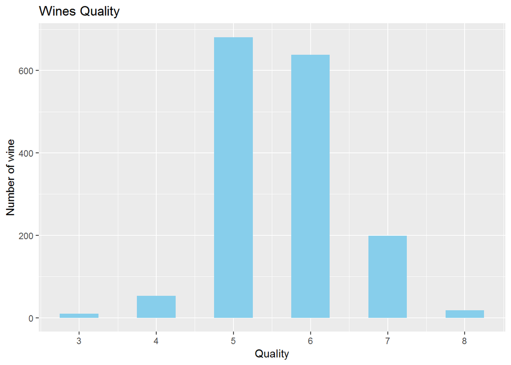

### Description One

In this plot We can see most of wines have a quality of 5 and 6, There are no wines with quality less than 3 or greater than 8 in this dataset.

### Plot Two

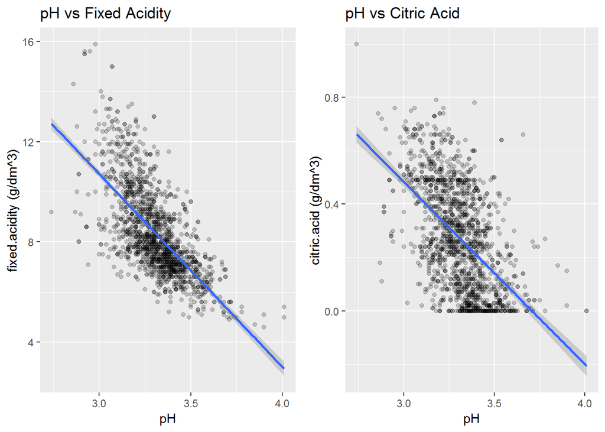

### Description Two

These are two scatter plots that shows a negative correlation between pH and fixed.acidity, pH and citric.acid Which means with highest pH we get lowest fixed.acidity andcitric.acid value.

### Plot Three

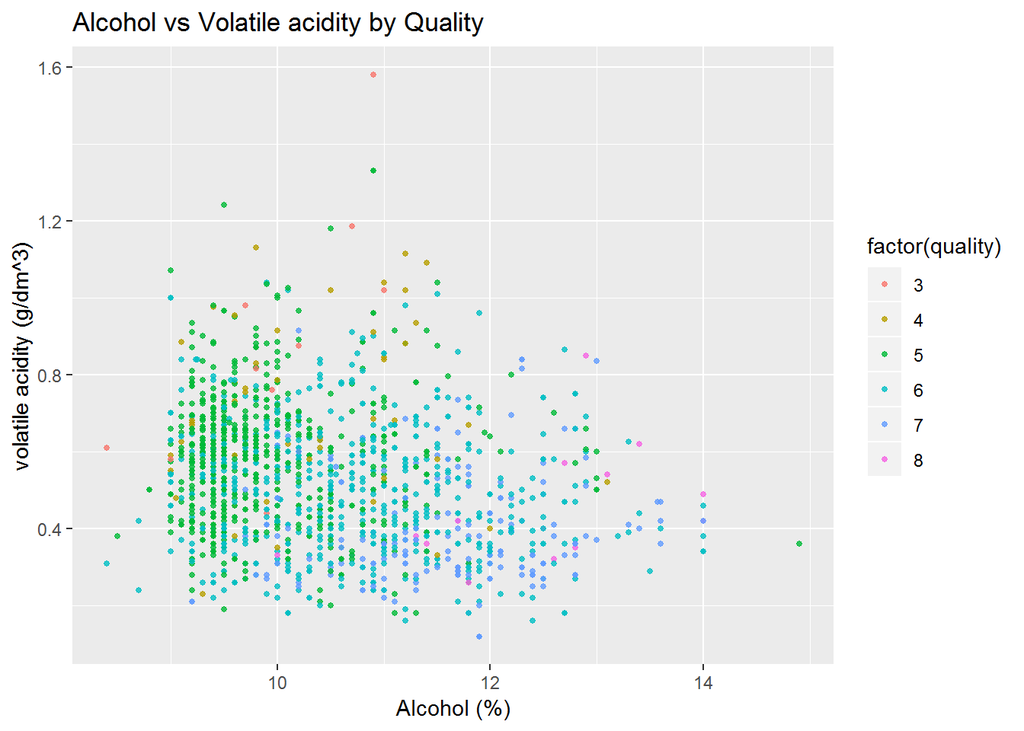

### Description Three

The quality of wine increases as we move towards the lower right of the plot.wine with quality 5 occurs the most when volatile acidity is between 0.4 and 0.8 and alcohol is between 8 and 10. Wine seems to have better quality when volatile acidity is around 0.3 and alcohol is between 11 and 13.Wines have lower quality when volatile acidity is 0.8 or higher as seen by the red points.

# Reflection

This data set contains information on 1,599 different red wines across 12 variable from a 2009 study.

I started exploring the distribution of individual variables and looked for unusual behaviors in the histograms.

One of the main interesting things in this data is that most of wines measured had a quality of 5 or 6 while qualities as 3,4 or 8 have very few samples. I guess it means that most of wines in this dataset has a normal quality and just a few have a high or low quality. I found that the wines that have higher quality when they are higher in alcohol percent and low density.

The main challenge I had were the fact the variables were not clearly explained as they represent chemical properties, So I made make sure that I understand them.

Also the dataset was tidy which makes it easy to work with as I didn’t have to struggle with cleaning the data. It would be interesting to include the prices of the wine to see if there is a relation between the prices and the quality of the wine.